# Case Study 3: Variable Selection

Kelly Bodwin

In this case study, you will continue to perform multiple regression, but you will be asked to think about which variables should or should not be included.

## Preliminary checks

First we will predict the price of a laptop based on many variables, both quantitative and categorial. Begin by downloading the data as usual. By now, you should find it natural to explore basic information about a dataset and its variables after downloading.

```r
laptops = read.csv("http://kbodwin.web.unc.edu/files/2016/10/laptops.csv")

summary(laptops)
```

```
##  Max.Horizontal.Resolution          Memory.Technology Installed.Memory
##  800    :51                DDR-SDRAM_(DDRRAM):20      Min.   : 250.0
##  768    :24                DDR2              :78      1st Qu.: 512.0
##  1050   : 9                SDRAM             : 1      Median :1000.0
##  900    : 6                                           Mean   : 907.6
##  854    : 3                                           3rd Qu.:1000.0
##  1200   : 2                                           Max.   :2000.0
##  (Other): 4
##  Processor.Speed              Processor                Manufacturer
##  Min.   : 867    AMD Mobile Sempron: 2   Acer                : 3
##  1st Qu.:1600    AMD Turion 64x2   : 5   Apple               :34
##  Median :1800    Intel Celeron     : 2   Asus                : 4
##  Mean   :1711    Intel Core2 Duo   :67   Fujitsu             : 7
##  3rd Qu.:2000    PowerPC           :23   HP_(Hewlett-Packard):28
##  Max.   :2330                            Lenovo              :22
##                                          Toshiba             : 1
##  Infrared Bluetooth Docking.Station Port.Replicator Fingerprint Subwoofer
##  NO :88   NO :50    NO :62          NO :62          NO :65      NO:99
##  YES:11   YES:49    YES:37          YES:37          YES:34
##
##
##
##
##
##  External.Battery CDMA          Operating.System Warranty.Days
##  NO :98           NO:99   Mac_OS        :34      Min.   : 365.0
##  YES: 1                   Vista_Business:65      1st Qu.: 365.0
##                                                  Median : 365.0
##                                                  Mean   : 489.9
##                                                  3rd Qu.: 365.0
##                                                  Max.   :1095.0
##
##      Price
##  Min.   : 539.0
##  1st Qu.: 796.5
##  Median :1075.0
##  Mean   :1091.9
##  3rd Qu.:1299.5
##  Max.   :1899.0
##
```

Summarize the data, and fix anything that seems nonsensical. (This should be your first step before any analysis.)

### Question 1:

1. Run the following code:

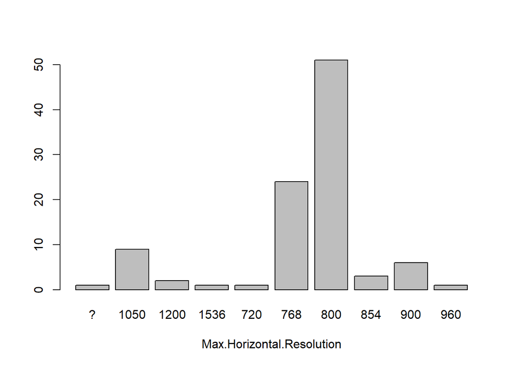

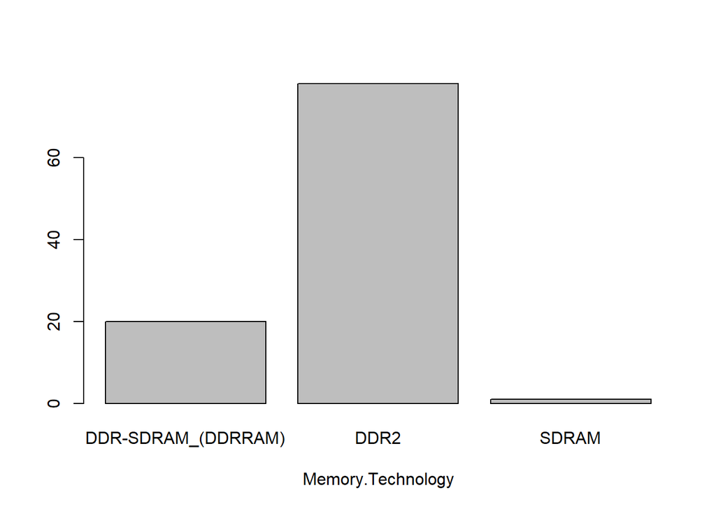

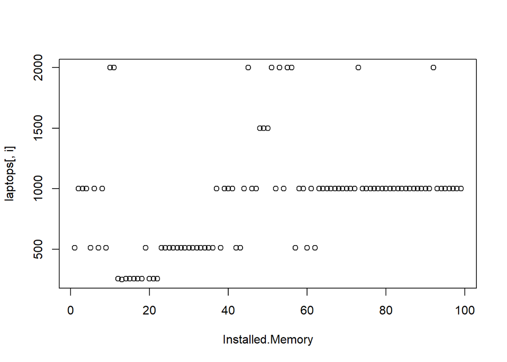

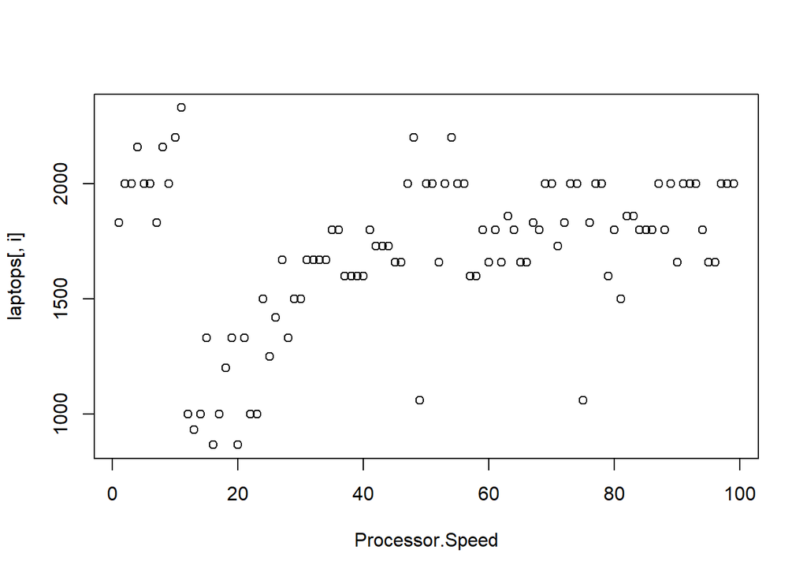

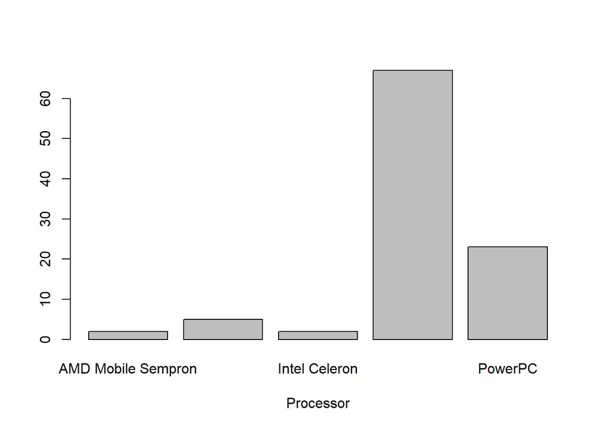

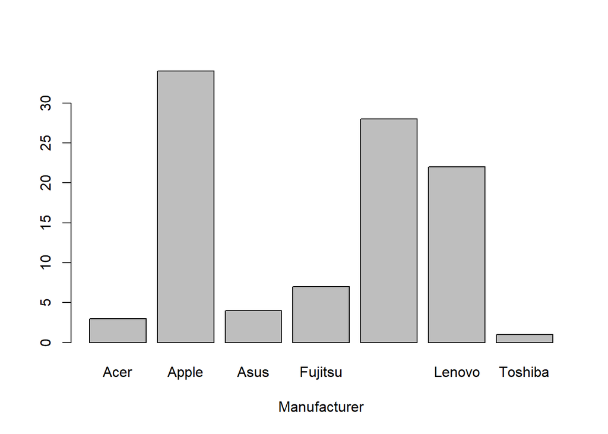

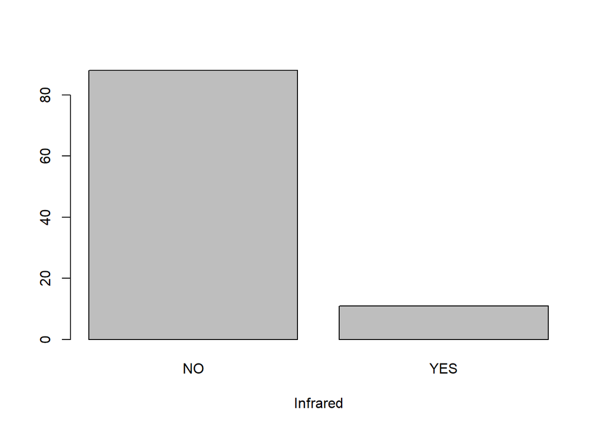

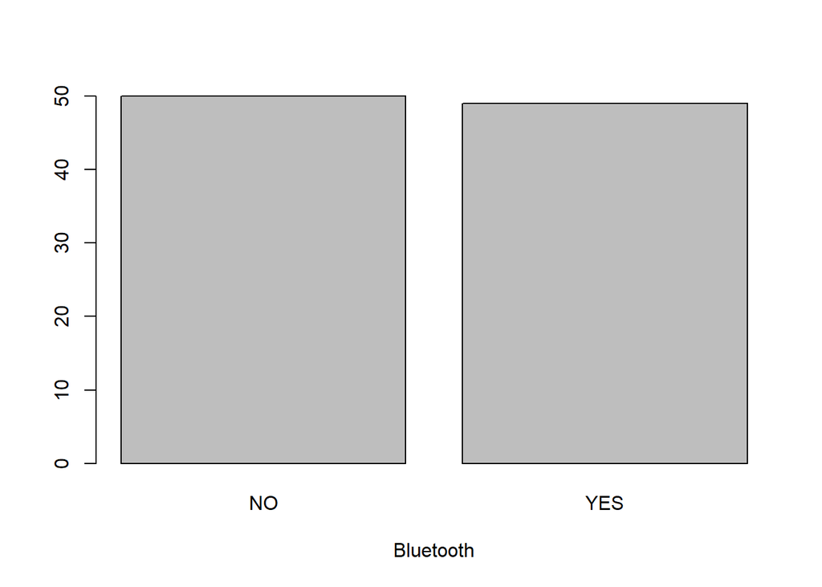

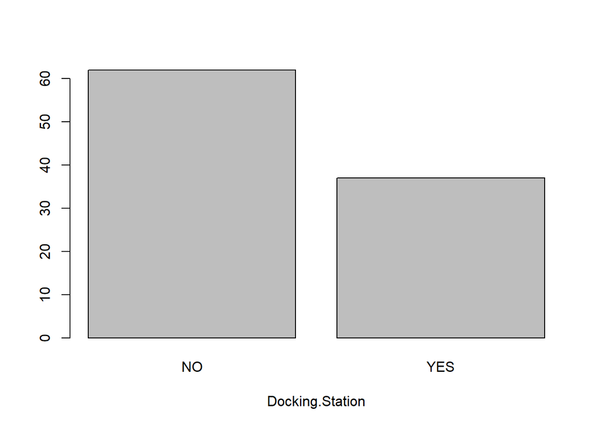

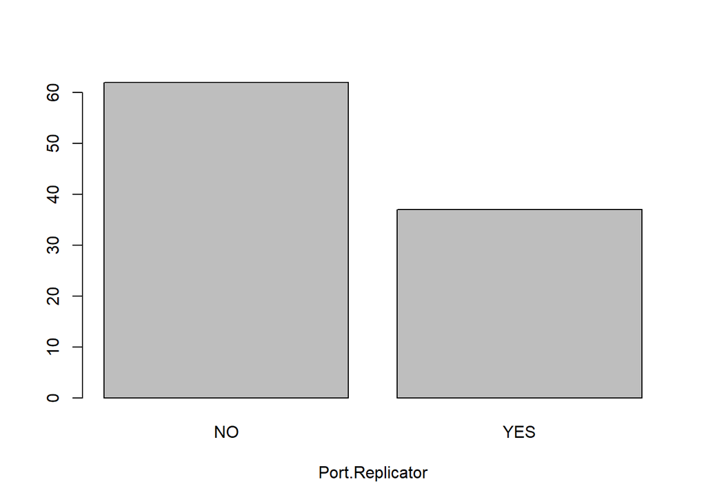

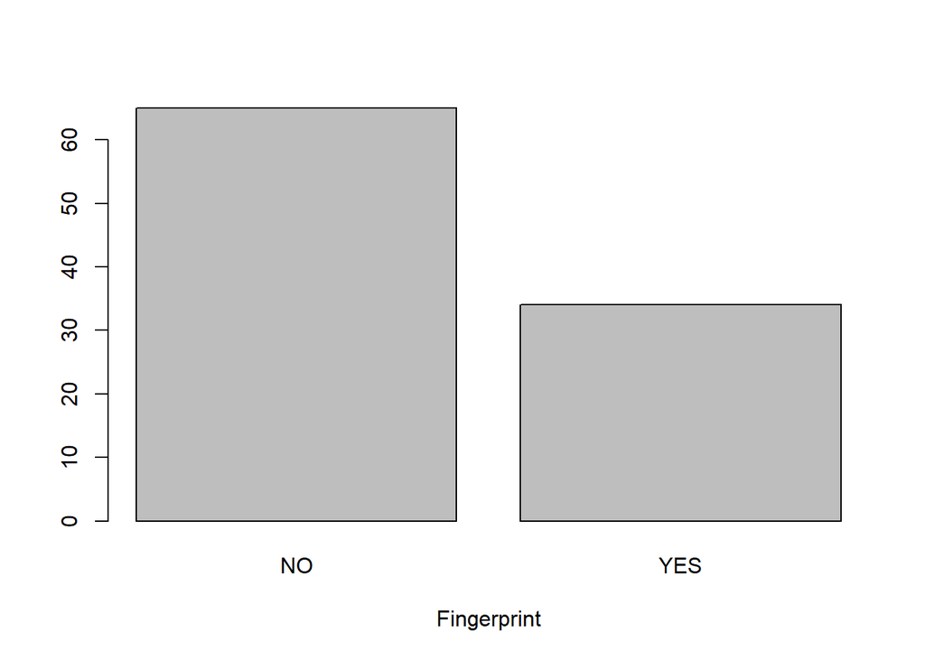

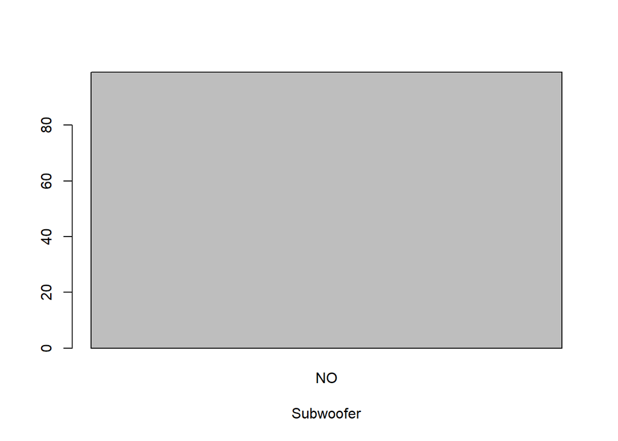

[5 more figures not shown]

```r
for(i in 1:ncol(laptops)){
  par(ask = TRUE)
  plot(laptops[,i], xlab = names(laptops)[i])
}
```

What did this do? What was the role of the line `par(ask = TRUE)`? How did we use the loop to get each variable name to print on the x-axis?

```
the for loop will iterate through each of the columns and retrieve the frequency and plot it if the data is categorical. Scatterplots are made for any columns with numerical data and the x-label is automatically set to the name of each column using names(laptops)[i]). The scatterplots are plotted alongisde themselves so the number the computer appears in the datafram is plotted on the x-axis while the column on the Y. Ask will prompt you to click return to generate each plot one by one.
```

As you looked at the plots, did anything stand out to you as a possible problem for regression?

```
None of the regression models show any resemblence of linear regression, given that all of the columns are plotted against themselves.
```

2. Alter the above code so that instead of plotting each variable alone, you plot it against `Price`. Comment on what you see.

```r
#class(laptops$Max.Horizontal.Resolution)
for(i in 1:ncol(laptops)){
  par(ask = TRUE)
  plot(laptops[,i],laptops$Price, xlab = names(laptops)[i],ylab = "price")
}
```

[output not shown]

**Note: When you are done with this question, change the code chunks to `eval = FALSE`, to avoid printing all the plots in your final output.**

### Question 2:

For each of the following regressions, explain what is wrong with the output of `lm( )`, and why exactly it occurred. Explain your answers with appropriate plots or tables where possible.

```r
# a
#lm_a = lm(Price ~ Subwoofer, data = laptops)


# b
lm_b = lm(Price ~ Max.Horizontal.Resolution^2, data = laptops)
summary(lm_b)
```

```
##
## Call:
## lm(formula = Price ~ Max.Horizontal.Resolution^2, data = laptops)
##
## Residuals:
##     Min      1Q  Median      3Q     Max
## -809.57 -212.61  -44.24  183.21  916.13
##
## Coefficients:
##                               Estimate Std. Error t value Pr(>|t|)
## (Intercept)                      749.0      337.8   2.217   0.0291 *
## Max.Horizontal.Resolution1050    581.7      356.1   1.634   0.1059
## Max.Horizontal.Resolution1200    395.5      413.7   0.956   0.3417
## Max.Horizontal.Resolution1536    126.0      477.7   0.264   0.7926
## Max.Horizontal.Resolution720     533.0      477.7   1.116   0.2676
## Max.Horizontal.Resolution768     228.1      344.8   0.662   0.5099
## Max.Horizontal.Resolution800     295.2      341.1   0.865   0.3891
## Max.Horizontal.Resolution854     739.6      390.1   1.896   0.0612 .
## Max.Horizontal.Resolution900     718.7      364.9   1.970   0.0520 .
## Max.Horizontal.Resolution960     200.0      477.7   0.419   0.6765
## ---
## Signif. codes:  0 '***' 0.001 '**' 0.01 '*' 0.05 '.' 0.1 ' ' 1
##
## Residual standard error: 337.8 on 89 degrees of freedom
## Multiple R-squared:  0.197,  Adjusted R-squared:  0.1158
## F-statistic: 2.426 on 9 and 89 DF,  p-value: 0.01629
```

```r
# c
lm_c = lm(Price ~ Manufacturer + Operating.System, data = laptops)
summary(lm_c)
```

```
##
## Call:
## lm(formula = Price ~ Manufacturer + Operating.System, data = laptops)
##
## Residuals:
##    Min     1Q Median     3Q    Max
## -497.4 -234.5    0.0  189.2  862.5
##
## Coefficients: (1 not defined because of singularities)
##                                  Estimate Std. Error t value Pr(>|t|)
## (Intercept)                        988.32     185.18   5.337 6.75e-07 ***
## ManufacturerApple                   48.13     193.18   0.249  0.80379
## ManufacturerAsus                   647.31     244.97   2.642  0.00967 **
## ManufacturerFujitsu                572.11     221.33   2.585  0.01131 *
## ManufacturerHP_(Hewlett-Packard)    24.67     194.85   0.127  0.89952
## ManufacturerLenovo                  72.25     197.40   0.366  0.71521
## ManufacturerToshiba               -258.32     370.36  -0.697  0.48726
## Operating.SystemVista_Business         NA         NA      NA       NA
## ---
## Signif. codes:  0 '***' 0.001 '**' 0.01 '*' 0.05 '.' 0.1 ' ' 1
##
## Residual standard error: 320.7 on 92 degrees of freedom
## Multiple R-squared:  0.2517, Adjusted R-squared:  0.2029
## F-statistic: 5.157 on 6 and 92 DF,  p-value: 0.000131
```

```r
# d
lm_d1 = lm(Price ~ Processor.Speed+Processor, data = laptops)
summary(lm_d1)
```

```
##
## Call:
## lm(formula = Price ~ Processor.Speed + Processor, data = laptops)
##
## Residuals:
##     Min      1Q  Median      3Q     Max
## -423.22 -191.50  -72.42   94.75 1186.80
##
## Coefficients:
##                           Estimate Std. Error t value Pr(>|t|)
## (Intercept)              -552.4900   310.8514  -1.777   0.0788 .
## Processor.Speed             0.6667     0.1289   5.172 1.33e-06 ***
## ProcessorAMD Turion 64x2  417.8347   245.6097   1.701   0.0922 .
## ProcessorIntel Celeron     64.0652   292.6619   0.219   0.8272
## ProcessorIntel Core2 Duo  507.9624   210.0407   2.418   0.0175 *
## ProcessorPowerPC          590.5116   225.3895   2.620   0.0103 *
## ---
## Signif. codes:  0 '***' 0.001 '**' 0.01 '*' 0.05 '.' 0.1 ' ' 1
##
## Residual standard error: 292.5 on 93 degrees of freedom
## Multiple R-squared:  0.3708, Adjusted R-squared:  0.3369
## F-statistic: 10.96 on 5 and 93 DF,  p-value: 2.607e-08
```

```r
lm_d2 = lm(Price ~ Processor.Speed*Processor, data = laptops)
summary(lm_d2)
```

```
##
## Call:
## lm(formula = Price ~ Processor.Speed * Processor, data = laptops)
##
## Residuals:
##     Min      1Q  Median      3Q     Max
## -474.45 -202.97  -43.66  113.41 1028.17
##
## Coefficients: (2 not defined because of singularities)
##                                            Estimate Std. Error t value
## (Intercept)                              -1248.3428   436.8108  -2.858
## Processor.Speed                              1.0533     0.2148   4.904
## ProcessorAMD Turion 64x2                  2758.2453  2675.6087   1.031
## ProcessorIntel Celeron                      91.1261   287.9812   0.316
## ProcessorIntel Core2 Duo                  1573.2546   527.1602   2.984
## ProcessorPowerPC                           787.0481   238.4775   3.300
## Processor.Speed:ProcessorAMD Turion 64x2    -1.3894     1.6220  -0.857
## Processor.Speed:ProcessorIntel Celeron           NA         NA      NA
## Processor.Speed:ProcessorIntel Core2 Duo    -0.5855     0.2665  -2.197
## Processor.Speed:ProcessorPowerPC                 NA         NA      NA
##                                          Pr(>|t|)
## (Intercept)                               0.00529 **
## Processor.Speed                          4.08e-06 ***
## ProcessorAMD Turion 64x2                  0.30533
## ProcessorIntel Celeron                    0.75240
## ProcessorIntel Core2 Duo                  0.00365 **
## ProcessorPowerPC                          0.00138 **
## Processor.Speed:ProcessorAMD Turion 64x2  0.39392
## Processor.Speed:ProcessorIntel Celeron         NA
## Processor.Speed:ProcessorIntel Core2 Duo  0.03055 *
## Processor.Speed:ProcessorPowerPC               NA
## ---
## Signif. codes:  0 '***' 0.001 '**' 0.01 '*' 0.05 '.' 0.1 ' ' 1
##
## Residual standard error: 287.6 on 91 degrees of freedom
## Multiple R-squared:  0.4049, Adjusted R-squared:  0.3591
## F-statistic: 8.845 on 7 and 91 DF,  p-value: 2.891e-08
```

```
lm_a is comparing subwoofer with price, but subwoofer only has one value: NO, and there is not enough variation in that column's data to calculate a linear model.
```

## ANOVA for nested models

Recall that we can use ANOVA tests to compare two multiple regressions, when one model is nested in the other. This is particularly useful when the models have many factors, so it might be hard to tell which variable is more significant from the t-scores.

### Question 3:

Consider the following model:

```r
  lm_3 = lm(Price ~ Port.Replicator + Bluetooth + Manufacturer , data = laptops)
  summary(lm_3)
```

```
##
## Call:
## lm(formula = Price ~ Port.Replicator + Bluetooth + Manufacturer,
##     data = laptops)
##
## Residuals:
##     Min      1Q  Median      3Q     Max
## -533.93 -191.23  -27.24  181.82  962.27
##
## Coefficients:
##                                  Estimate Std. Error t value Pr(>|t|)
## (Intercept)                        988.32     170.84   5.785 1.04e-07 ***
## Port.ReplicatorYES                 184.96      85.00   2.176  0.03217 *
## BluetoothYES                       205.30      63.33   3.242  0.00167 **
## ManufacturerApple                  -66.59     181.69  -0.367  0.71484
## ManufacturerAsus                   442.01     234.70   1.883  0.06289 .
## ManufacturerFujitsu                378.44     210.59   1.797  0.07569 .
## ManufacturerHP_(Hewlett-Packard)  -202.03     191.15  -1.057  0.29336
## ManufacturerLenovo                -122.88     188.48  -0.652  0.51610
## ManufacturerToshiba               -443.28     352.09  -1.259  0.21129
## ---
## Signif. codes:  0 '***' 0.001 '**' 0.01 '*' 0.05 '.' 0.1 ' ' 1
##
## Residual standard error: 295.9 on 90 degrees of freedom
## Multiple R-squared:  0.3769, Adjusted R-squared:  0.3216
## F-statistic: 6.806 on 8 and 90 DF,  p-value: 5.865e-07
```

If you had to remove exactly one of the three variables from the model, which one would you remove? Why?

```r
  lm_2= lm(Price ~  Bluetooth + Manufacturer , data = laptops)
  summary(lm_2)
```

```
##
## Call:
## lm(formula = Price ~ Bluetooth + Manufacturer, data = laptops)
##
## Residuals:
##    Min     1Q Median     3Q    Max
## -541.9 -199.5  -24.7  164.5  975.1
##
## Coefficients:
##                                  Estimate Std. Error t value Pr(>|t|)
## (Intercept)                        988.32     174.31   5.670 1.67e-07 ***
## BluetoothYES                       228.25      63.71   3.582 0.000549 ***
## ManufacturerApple                  -79.42     185.29  -0.429 0.669221
## ManufacturerAsus                   419.07     239.23   1.752 0.083185 .
## ManufacturerFujitsu                474.29     210.12   2.257 0.026385 *
## ManufacturerHP_(Hewlett-Packard)   -73.15     185.43  -0.394 0.694150
## ManufacturerLenovo                 -41.87     188.52  -0.222 0.824722
## ManufacturerToshiba               -258.32     348.62  -0.741 0.460614
## ---
## Signif. codes:  0 '***' 0.001 '**' 0.01 '*' 0.05 '.' 0.1 ' ' 1
##
## Residual standard error: 301.9 on 91 degrees of freedom
## Multiple R-squared:  0.3442, Adjusted R-squared:  0.2937
## F-statistic: 6.822 on 7 and 91 DF,  p-value: 1.642e-06
```

[output not shown]

### Question 4:

Consider the issue you noticed in 2(d). Soon, we will want to build our full regression model, and we will have to decide whether to include `Operating.System` or `Manufacturer`. Regress each of these two variables individually against `Price`. Which one would you rather include in the full model? Justify your answer.

```r
    man = lm(Price ~ Manufacturer , data = laptops)
    summary(man)
```

```
##
## Call:
## lm(formula = Price ~ Manufacturer, data = laptops)
##
## Residuals:
##    Min     1Q Median     3Q    Max
## -497.4 -234.5    0.0  189.2  862.5
##
## Coefficients:
##                                  Estimate Std. Error t value Pr(>|t|)
## (Intercept)                        988.32     185.18   5.337 6.75e-07 ***
## ManufacturerApple                   48.13     193.18   0.249  0.80379
## ManufacturerAsus                   647.31     244.97   2.642  0.00967 **
## ManufacturerFujitsu                572.11     221.33   2.585  0.01131 *
## ManufacturerHP_(Hewlett-Packard)    24.67     194.85   0.127  0.89952
## ManufacturerLenovo                  72.25     197.40   0.366  0.71521
## ManufacturerToshiba               -258.32     370.36  -0.697  0.48726
## ---
## Signif. codes:  0 '***' 0.001 '**' 0.01 '*' 0.05 '.' 0.1 ' ' 1
##
## Residual standard error: 320.7 on 92 degrees of freedom
## Multiple R-squared:  0.2517, Adjusted R-squared:  0.2029
## F-statistic: 5.157 on 6 and 92 DF,  p-value: 0.000131
```

```r
    os = lm(Price ~ Operating.System, data = laptops)
    summary(os)
```

```
##
## Call:
## lm(formula = Price ~ Operating.System, data = laptops)
##
## Residuals:
##    Min     1Q Median     3Q    Max
## -521.9 -271.4  -36.5  215.8  862.5
##
## Coefficients:
##                                Estimate Std. Error t value Pr(>|t|)
## (Intercept)                     1036.45      61.54  16.843   <2e-16 ***
## Operating.SystemVista_Business    84.42      75.94   1.112    0.269
## ---
## Signif. codes:  0 '***' 0.001 '**' 0.01 '*' 0.05 '.' 0.1 ' ' 1
##
## Residual standard error: 358.8 on 97 degrees of freedom
## Multiple R-squared:  0.01258,    Adjusted R-squared:  0.0024
## F-statistic: 1.236 on 1 and 97 DF,  p-value: 0.269
```

```
Based on the R-squared values, Manufacturer seems to fit price much better (.2029) than OS(.0024). In addition OS has a high p-value of .269, which leads to the conclusion that it is not safe to reject that OS is significant towards the Price. In this case would remove OS.
```

## Collinearity

Recall from lecture that one major concern in Multiple Regression is *collinearity*, or correlation between explanatory variables. One way to measure this is through the Variance Inflation Factor. Use the code below to install an **R** package that will calculate this, as well as to get rid of the useless variables we discovered in Questions 1-4.

```r
  #Install vif package
  require("car")
  # Get rid of identified useless variables
  bad = c("Port.Replicator", "Subwoofer", "CDMA")

  lt = laptops[, !(names(laptops) %in% bad)]
```

### Question 5:

Try the following regression, and then use `vif( )` to check for collinearity. Are there any variables we should be worried about? Decide which ones to remove (if any) from `lt`.

```r
  library(car)
  lm_4 = lm(Price ~ .-Operating.System, data = lt)
  vif(lm_4)
```

```
##                                 GVIF Df GVIF^(1/(2*Df))
## Max.Horizontal.Resolution  47.082687  9        1.238616
## Memory.Technology          23.709272  2        2.206630
## Installed.Memory            4.037496  1        2.009352
## Processor.Speed             4.751322  1        2.179753
## Processor                 125.080654  4        1.828727
## Manufacturer               71.633264  6        1.427555
## Infrared                    1.863913  1        1.365252
## Bluetooth                   2.343923  1        1.530988
## Docking.Station             3.774785  1        1.942881
## Fingerprint                 2.381911  1        1.543344
## External.Battery            1.304795  1        1.142276
## Warranty.Days               2.102269  1        1.449920
```

[output not shown]

### Question 6:

Compare the following regressions via `anova( )`, and look at `vif( )` for each. Make an argument for keeping either `Manufacturer` or `Operating.System` in your final regression.

```r
  lm_5 = lm(Price ~ .-Manufacturer, data = lt)
  anova(lm_5)
```

```
## Analysis of Variance Table
##
## Response: Price
##                           Df  Sum Sq Mean Sq F value    Pr(>F)
## Max.Horizontal.Resolution  9 2491659  276851  5.5166 8.650e-06 ***
## Memory.Technology          2 3380390 1690195 33.6789 3.979e-11 ***
## Installed.Memory           1  799510  799510 15.9311 0.0001532 ***
## Processor.Speed            1  704153  704153 14.0310 0.0003536 ***
## Processor                  4  657533  164383  3.2755 0.0157687 *
## Infrared                   1  209690  209690  4.1783 0.0445037 *
## Bluetooth                  1  119804  119804  2.3872 0.1265968
## Docking.Station            1   34847   34847  0.6944 0.4073663
## Fingerprint                1   95392   95392  1.9008 0.1721442
## External.Battery           1  118626  118626  2.3638 0.1284477
## Operating.System           1   70488   70488  1.4046 0.2397546
## Warranty.Days              1  251401  251401  5.0094 0.0282179 *
## Residuals                 74 3713727   50186
## ---
## Signif. codes:  0 '***' 0.001 '**' 0.01 '*' 0.05 '.' 0.1 ' ' 1
```

```r
  vif(lm_5)
```

```
##                                GVIF Df GVIF^(1/(2*Df))
## Max.Horizontal.Resolution 19.637480  9        1.179881
## Memory.Technology         23.069043  2        2.191580
## Installed.Memory           3.159338  1        1.777453
## Processor.Speed            4.308826  1        2.075771
## Processor                 46.398850  4        1.615524
## Infrared                   1.600303  1        1.265031
## Bluetooth                  2.207542  1        1.485780
## Docking.Station            3.119849  1        1.766309
## Fingerprint                2.143705  1        1.464140
## External.Battery           1.274029  1        1.128729
## Operating.System           4.362984  1        2.088776
## Warranty.Days              1.909692  1        1.381916
```

```r
  lm_6 = lm(Price ~ .-Operating.System, data = lt)

  anova(lm_6)
```

```
## Analysis of Variance Table
##
## Response: Price
##                           Df  Sum Sq Mean Sq F value    Pr(>F)
## Max.Horizontal.Resolution  9 2491659  276851  7.8784 6.770e-08 ***
## Memory.Technology          2 3380390 1690195 48.0981 8.304e-14 ***
## Installed.Memory           1  799510  799510 22.7518 9.929e-06 ***
## Processor.Speed            1  704153  704153 20.0382 2.922e-05 ***
## Processor                  4  657533  164383  4.6779  0.002123 **
## Manufacturer               6 1349994  224999  6.4028 2.140e-05 ***
## Infrared                   1  184595  184595  5.2530  0.024964 *
## Bluetooth                  1    7299    7299  0.2077  0.649999
## Docking.Station            1  326164  326164  9.2817  0.003278 **
## Fingerprint                1   40860   40860  1.1627  0.284652
## External.Battery           1   98092   98092  2.7914  0.099301 .
## Warranty.Days              1  182276  182276  5.1870  0.025859 *
## Residuals                 69 2424697   35141
## ---
## Signif. codes:  0 '***' 0.001 '**' 0.01 '*' 0.05 '.' 0.1 ' ' 1
```

```r
  vif(lm_6)
```

```
##                                 GVIF Df GVIF^(1/(2*Df))
## Max.Horizontal.Resolution  47.082687  9        1.238616
## Memory.Technology          23.709272  2        2.206630
## Installed.Memory            4.037496  1        2.009352
## Processor.Speed             4.751322  1        2.179753
## Processor                 125.080654  4        1.828727
## Manufacturer               71.633264  6        1.427555
## Infrared                    1.863913  1        1.365252
## Bluetooth                   2.343923  1        1.530988
## Docking.Station             3.774785  1        1.942881
## Fingerprint                 2.381911  1        1.543344
## External.Battery            1.304795  1        1.142276
## Warranty.Days               2.102269  1        1.449920
```

[output not shown]

## Narrowing down the model

We have now established a final set of candidate variables from which to predict the price of laptops. Install the **R** package called “leaps”. This package automatically performs several types of variable selection.

### Question 7

1. Look at the documentation for the function `regsubsets( )`. How many types of variable selection can be performed? What are they? Which measures of model fit does the function output?

```
4 selection methods can be performed. the 4 include: forward, backward, exhaustive, and squential replacement
```

2. Apply `regsubsets( )` to a regression predicting `Price` from all reasonable variables, using forward selection. Plot the results by using `plot( )` on the output. Use the option `scale = "adjr2"` inside `plot( )` to change the measure of model fit to be adjusted R-squared.

```r
require(leaps)
```

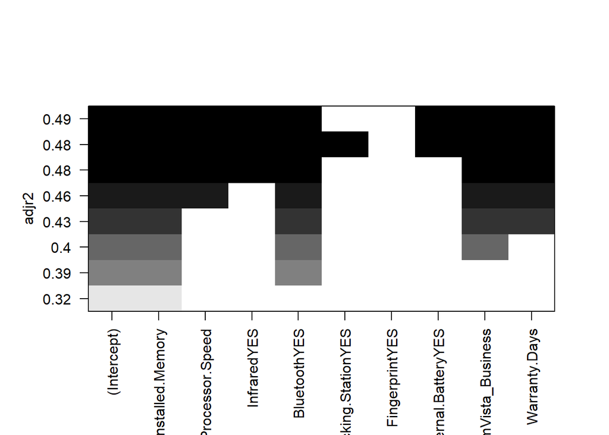

```r
something = regsubsets(Price ~ Installed.Memory + Processor.Speed + Infrared + Bluetooth + Docking.Station + Fingerprint + External.Battery + Operating.System + Warranty.Days, data = lt, method = "forward")

plot(something,scale="adjr2")
```

3. Using `regsubsets( )` to search exhaustively, and using Mallow’s Cp as the measure of model fit, what is the best model for predicting `Price`?

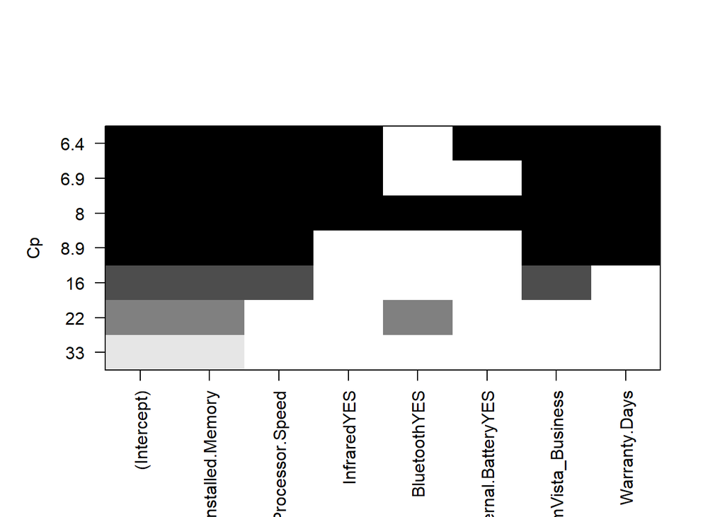

[output not shown]

```r
exhaust = regsubsets(Price ~Installed.Memory + Processor.Speed+Infrared + Bluetooth  + External.Battery + Operating.System + Warranty.Days, data = lt, method = "exhaustive")

plot(exhaust,scale="Cp")
```

### Question 8

Use your final model in 6c for the following: a. Make a plot of the predicted prices of each laptop in the dataset versus the true prices. *Hint: use `predict( )`* Is there anything we might be concerned about from these predictions?

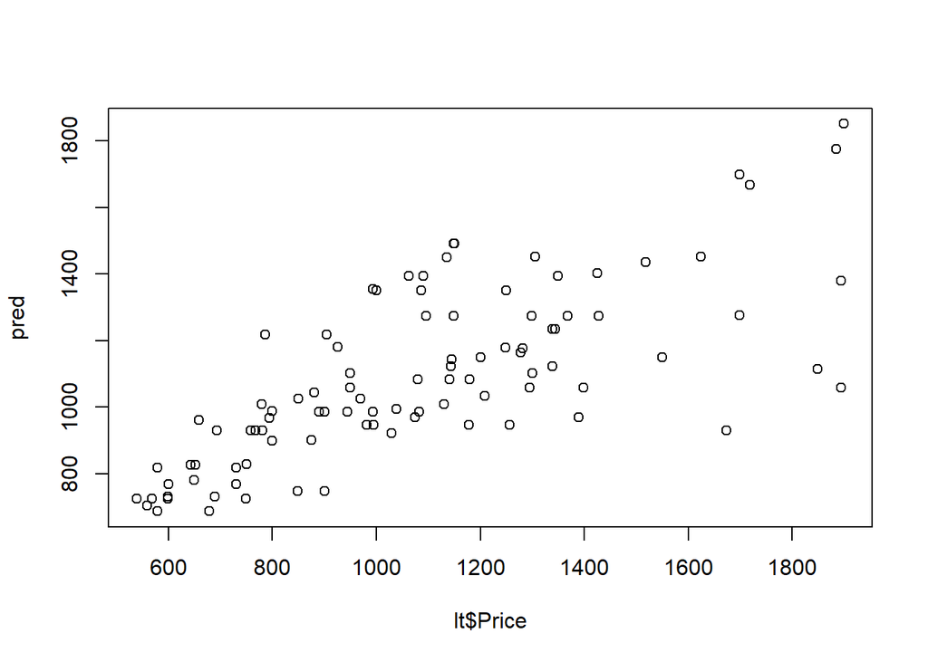

```
the graph of observed prices vs predicted prices is roughly linear, but alot of outliers toward the right side of the scatterplot. Excercise caution when using this model.
```

```r
    lm_new = lm(Price ~Installed.Memory + Processor.Speed+Infrared + Bluetooth  + External.Battery + Operating.System + Warranty.Days, data = lt)
    pred= predict(lm_new)
    plot(lt$Price,pred,xlab=)
```

2. Look at some diagnostic plots and/or measurements for your final model, and comment on them.

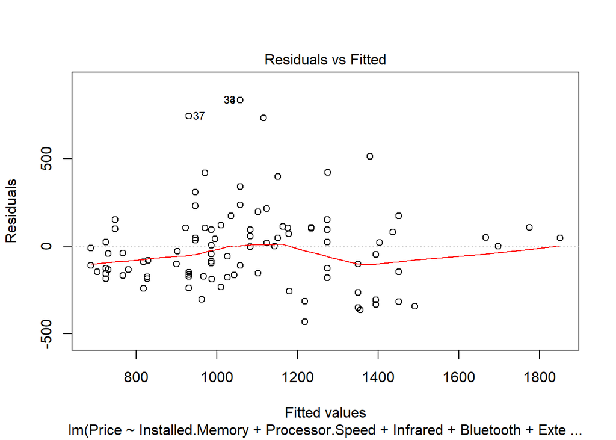

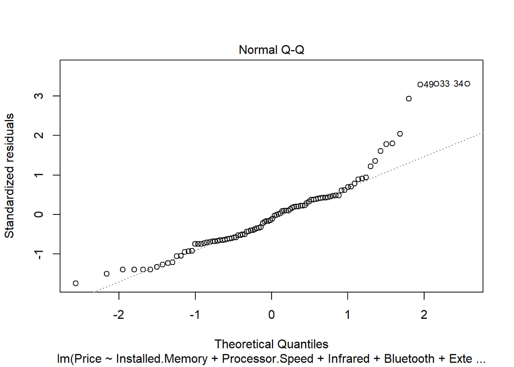

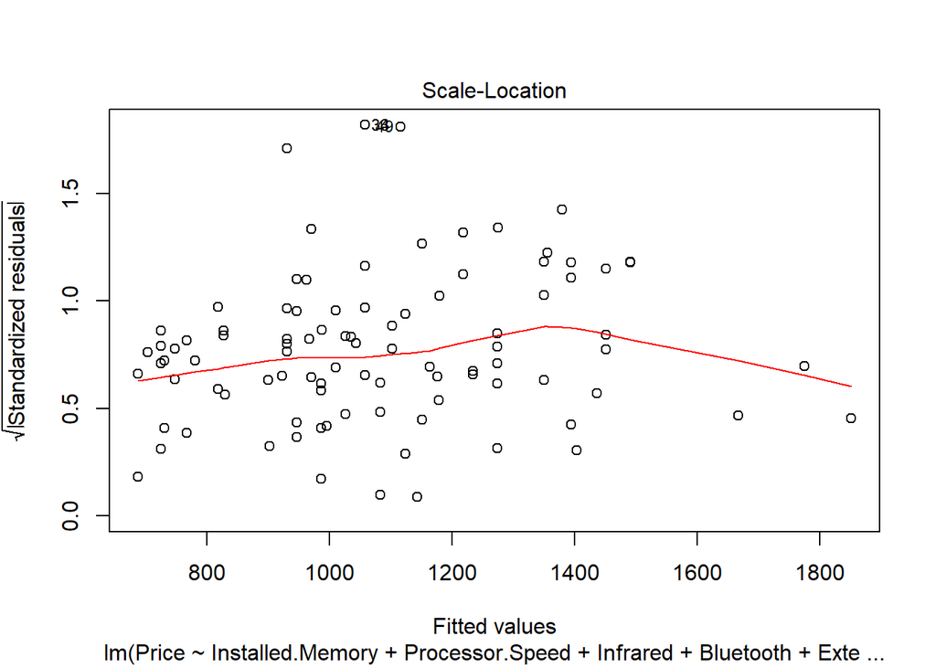

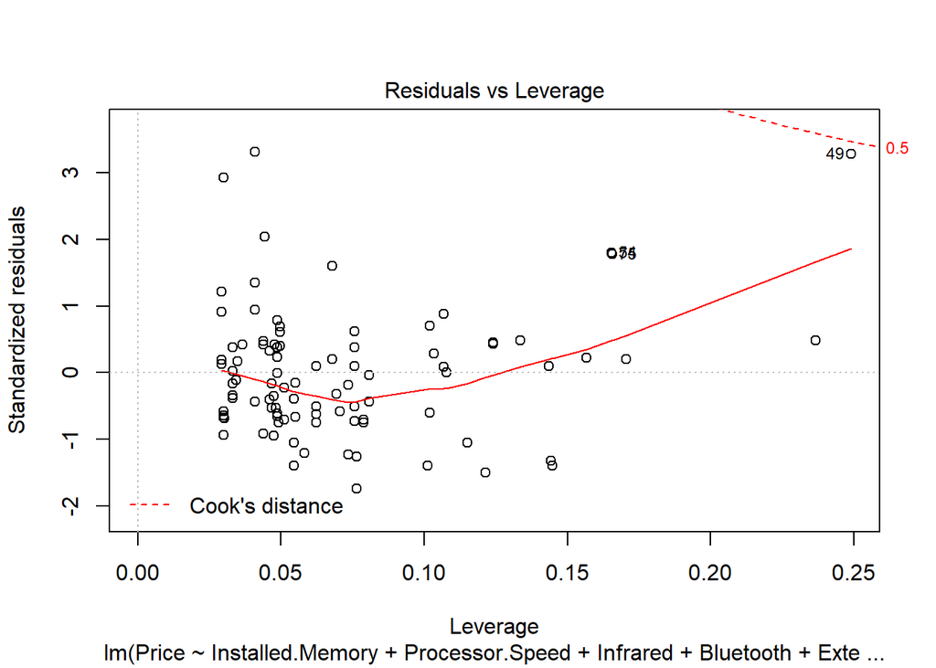

```r
    plot(lm_new)
```

```r
  summary(lm_new)
```

```
##
## Call:
## lm(formula = Price ~ Installed.Memory + Processor.Speed + Infrared +
##     Bluetooth + External.Battery + Operating.System + Warranty.Days,
##     data = lt)
##
## Residuals:
##     Min      1Q  Median      3Q     Max
## -431.93 -163.00  -26.93  104.78  835.83
##
## Coefficients:
##                                  Estimate Std. Error t value Pr(>|t|)
## (Intercept)                     242.70576  156.61658   1.550 0.124689
## Installed.Memory                  0.40833    0.07739   5.276 8.88e-07 ***
## Processor.Speed                   0.28151    0.11497   2.449 0.016258 *
## InfraredYES                     176.36349   85.93095   2.052 0.043004 *
## BluetoothYES                     39.72714   64.70736   0.614 0.540780
## External.BatteryYES             423.78060  267.25406   1.586 0.116280
## Operating.SystemVista_Business -267.28129   72.53899  -3.685 0.000389 ***
## Warranty.Days                     0.26275    0.11209   2.344 0.021253 *
## ---
## Signif. codes:  0 '***' 0.001 '**' 0.01 '*' 0.05 '.' 0.1 ' ' 1
##
## Residual standard error: 257.7 on 91 degrees of freedom
## Multiple R-squared:  0.5222, Adjusted R-squared:  0.4854
## F-statistic: 14.21 on 7 and 91 DF,  p-value: 2.436e-12
```

[output not shown]

## Your Turn

Suppose you are consulting in marketing. One of your clients, Cooper, says “Customers treat all PC manufacturers the same. People only pay more for some brands because those laptops happen to include better features.” Another client, Tina, says “No, customers have a preference for specific manufacturers, and they will pay more for these brands even if the laptops are otherwise identical.”

Based on this dataset, who do you think is right, Cooper or Tina? Do you believe price differences in PCs are only due to different features, or is there a manufacturer effect as well? Be creative in your answer; go beyond your response to Question 5. Make sure to support your argument with plots and clear explanations.

*Note: A “PC” in this case refers any laptop that is not made by Apple.*

```r
no_apple = laptops[laptops$Manufacturer != "Apple",]

app_lm = lm(Price ~ Installed.Memory + Processor.Speed + Infrared + Bluetooth + External.Battery + Warranty.Days+ Manufacturer, data = no_apple)
appy_lm = lm(Price ~ Installed.Memory + Processor.Speed + Infrared + Bluetooth + External.Battery + Warranty.Days+ Manufacturer, data = lt)

Manu_lm = lm(Price ~ Installed.Memory + Manufacturer:Processor.Speed + Infrared + Bluetooth + External.Battery + Warranty.Days, data = lt)

summary(app_lm)
```

```
##
## Call:
## lm(formula = Price ~ Installed.Memory + Processor.Speed + Infrared +
##     Bluetooth + External.Battery + Warranty.Days + Manufacturer,
##     data = no_apple)
##
## Residuals:
##    Min     1Q Median     3Q    Max
## -403.3 -127.6    0.0  130.0  355.9
##
## Coefficients:
##                                    Estimate Std. Error t value Pr(>|t|)
## (Intercept)                      528.694737 252.229458   2.096 0.040866
## Installed.Memory                   0.249091   0.078370   3.178 0.002472
## Processor.Speed                   -0.006751   0.130720  -0.052 0.959008
## InfraredYES                      145.697918  68.527957   2.126 0.038170
## BluetoothYES                     -54.485022  58.043215  -0.939 0.352144
## External.BatteryYES              568.367083 196.946674   2.886 0.005634
## Warranty.Days                      0.380451   0.087127   4.367 5.89e-05
## ManufacturerAsus                 557.248445 152.600987   3.652 0.000597
## ManufacturerFujitsu              454.516288 138.494010   3.282 0.001828
## ManufacturerHP_(Hewlett-Packard)   3.240271 122.225387   0.027 0.978950
## ManufacturerLenovo               101.370608 122.207518   0.829 0.410545
## ManufacturerToshiba              -53.415127 225.811862  -0.237 0.813920
##
## (Intercept)                      *
## Installed.Memory                 **
## Processor.Speed
## InfraredYES                      *
## BluetoothYES
## External.BatteryYES              **
## Warranty.Days                    ***
## ManufacturerAsus                 ***
## ManufacturerFujitsu              **
## ManufacturerHP_(Hewlett-Packard)
## ManufacturerLenovo
## ManufacturerToshiba
## ---
## Signif. codes:  0 '***' 0.001 '**' 0.01 '*' 0.05 '.' 0.1 ' ' 1
##
## Residual standard error: 187.1 on 53 degrees of freedom
## Multiple R-squared:  0.7214, Adjusted R-squared:  0.6636
## F-statistic: 12.47 on 11 and 53 DF,  p-value: 3.626e-11
```

```r
summary(appy_lm)
```

```
##
## Call:
## lm(formula = Price ~ Installed.Memory + Processor.Speed + Infrared +
##     Bluetooth + External.Battery + Warranty.Days + Manufacturer,
##     data = lt)
##
## Residuals:
##     Min      1Q  Median      3Q     Max
## -473.20 -146.87  -26.99  104.04  834.87
##
## Coefficients:
##                                    Estimate Std. Error t value Pr(>|t|)
## (Intercept)                      -121.53994  217.14129  -0.560 0.577120
## Installed.Memory                    0.27100    0.08125   3.335 0.001260
## Processor.Speed                     0.37999    0.11012   3.451 0.000869
## InfraredYES                       132.30174   87.07736   1.519 0.132340
## BluetoothYES                      -14.14243   62.45747  -0.226 0.821402
## External.BatteryYES               485.58446  249.53589   1.946 0.054926
## Warranty.Days                       0.29827    0.10796   2.763 0.007009
## ManufacturerApple                 311.96344  158.26157   1.971 0.051918
## ManufacturerAsus                  494.24484  191.62063   2.579 0.011600
## ManufacturerFujitsu               347.03104  173.21692   2.003 0.048278
## ManufacturerHP_(Hewlett-Packard)   -9.49658  152.60579  -0.062 0.950524
## ManufacturerLenovo                 44.89064  152.55628   0.294 0.769271
## ManufacturerToshiba               -53.47017  283.68366  -0.188 0.850940
##
## (Intercept)
## Installed.Memory                 **
## Processor.Speed                  ***
## InfraredYES
## BluetoothYES
## External.BatteryYES              .
## Warranty.Days                    **
## ManufacturerApple                .
## ManufacturerAsus                 *
## ManufacturerFujitsu              *
## ManufacturerHP_(Hewlett-Packard)
## ManufacturerLenovo
## ManufacturerToshiba
## ---
## Signif. codes:  0 '***' 0.001 '**' 0.01 '*' 0.05 '.' 0.1 ' ' 1
##
## Residual standard error: 238.2 on 86 degrees of freedom
## Multiple R-squared:  0.6141, Adjusted R-squared:  0.5603
## F-statistic: 11.41 on 12 and 86 DF,  p-value: 2.648e-13
```

```r
summary(lm_new)
```

```
##
## Call:
## lm(formula = Price ~ Installed.Memory + Processor.Speed + Infrared +
##     Bluetooth + External.Battery + Operating.System + Warranty.Days,
##     data = lt)
##
## Residuals:
##     Min      1Q  Median      3Q     Max
## -431.93 -163.00  -26.93  104.78  835.83
##
## Coefficients:
##                                  Estimate Std. Error t value Pr(>|t|)
## (Intercept)                     242.70576  156.61658   1.550 0.124689
## Installed.Memory                  0.40833    0.07739   5.276 8.88e-07 ***
## Processor.Speed                   0.28151    0.11497   2.449 0.016258 *
## InfraredYES                     176.36349   85.93095   2.052 0.043004 *
## BluetoothYES                     39.72714   64.70736   0.614 0.540780
## External.BatteryYES             423.78060  267.25406   1.586 0.116280
## Operating.SystemVista_Business -267.28129   72.53899  -3.685 0.000389 ***
## Warranty.Days                     0.26275    0.11209   2.344 0.021253 *
## ---
## Signif. codes:  0 '***' 0.001 '**' 0.01 '*' 0.05 '.' 0.1 ' ' 1
##
## Residual standard error: 257.7 on 91 degrees of freedom
## Multiple R-squared:  0.5222, Adjusted R-squared:  0.4854
## F-statistic: 14.21 on 7 and 91 DF,  p-value: 2.436e-12
```

```r
summary(Manu_lm)
```

```
##
## Call:
## lm(formula = Price ~ Installed.Memory + Manufacturer:Processor.Speed +
##     Infrared + Bluetooth + External.Battery + Warranty.Days,
##     data = lt)
##
## Residuals:
##     Min      1Q  Median      3Q     Max
## -471.33 -137.76  -17.24  115.33  817.76
##
## Coefficients:
##                                                   Estimate Std. Error
## (Intercept)                                      138.31345  149.32976
## Installed.Memory                                   0.29794    0.07884
## InfraredYES                                      140.79831   87.27452
## BluetoothYES                                      -8.78646   61.36055
## External.BatteryYES                              510.68341  249.15586
## Warranty.Days                                      0.34317    0.10862
## ManufacturerAcer:Processor.Speed                   0.19369    0.14000
## ManufacturerApple:Processor.Speed                  0.40016    0.11098
## ManufacturerAsus:Processor.Speed                   0.42753    0.13031
## ManufacturerFujitsu:Processor.Speed                0.38483    0.12285
## ManufacturerHP_(Hewlett-Packard):Processor.Speed   0.19204    0.10636
## ManufacturerLenovo:Processor.Speed                 0.23316    0.10575
## ManufacturerToshiba:Processor.Speed                0.18144    0.16389
##                                                  t value Pr(>|t|)
## (Intercept)                                        0.926 0.356919
## Installed.Memory                                   3.779 0.000290 ***
## InfraredYES                                        1.613 0.110347
## BluetoothYES                                      -0.143 0.886472
## External.BatteryYES                                2.050 0.043445 *
## Warranty.Days                                      3.159 0.002182 **
## ManufacturerAcer:Processor.Speed                   1.383 0.170094
## ManufacturerApple:Processor.Speed                  3.606 0.000521 ***
## ManufacturerAsus:Processor.Speed                   3.281 0.001496 **
## ManufacturerFujitsu:Processor.Speed                3.133 0.002369 **
## ManufacturerHP_(Hewlett-Packard):Processor.Speed   1.805 0.074502 .
## ManufacturerLenovo:Processor.Speed                 2.205 0.030128 *
## ManufacturerToshiba:Processor.Speed                1.107 0.271352
## ---
## Signif. codes:  0 '***' 0.001 '**' 0.01 '*' 0.05 '.' 0.1 ' ' 1
##
## Residual standard error: 237.1 on 86 degrees of freedom
## Multiple R-squared:  0.6178, Adjusted R-squared:  0.5645
## F-statistic: 11.58 on 12 and 86 DF,  p-value: 1.809e-13
```

```r
vif(Manu_lm)
```

```
##                                  GVIF Df GVIF^(1/(2*Df))
## Installed.Memory             2.256442  1        1.502146
## Infrared                     1.325041  1        1.151104
## Bluetooth                    1.657768  1        1.287543
## External.Battery             1.093320  1        1.045620
## Warranty.Days                1.459320  1        1.208023
## Manufacturer:Processor.Speed 5.626755  7        1.131331
```

[output not shown]